# Project: Investigate a Dataset - [Soccer Database]

- Introduction
- Data Wrangling
- Data Cleaning
- Exploratory Data Analysis
- Conclusions

## Introduction

### Dataset Description

This soccer database comes from Kaggle and is well suited for data analysis and machine learning. It contains data for soccer matches, players, and teams from several European countries from 2008 to 2016. This dataset is quite extensive.

### Question(s) for Analysis

- Which teams are the top performers overall from 2008 to 2016?
- Which league had the most goals scored per season?
- Is there any advantage in playing matches at home?
- which teams are the top performers at home and in away matches?
- Which teams had the most wins in a single season?
- Which teams improved the most over the time period?
- What are the attributes of the top teams?
- what are the attributes of the top players in 2016? and Does age play a factor in that?

```python
# Impoting useful packages
import os
import pandas as pd
import numpy as np
import matplotlib.pyplot as plt
import seaborn as sns
%matplotlib inline
import matplotlib
matplotlib.style.use('ggplot')
```

## Data Wrangling

### General Properties

#### Loading data

```python
# get the correct path of the csv files so we can work on them directly
os.chdir("Database_Soccer")
```

```python
#Load data from csv files
df_Country = pd.read_csv('Country.csv')
df_League = pd.read_csv('League.csv')
df_Match = pd.read_csv('Match.csv')
df_Player = pd.read_csv('Player.csv')
df_Player_Attributes = pd.read_csv('Player_Attributes.csv')
df_sqlite_sequence = pd.read_csv('sqlite_sequence.csv')
df_Team = pd.read_csv('Team.csv')
df_Team_Attributes = pd.read_csv('Team_Attributes.csv')
```

#### Understanding our data

Let's gather some information about the data available to us, shape, columns and what everything means

```python
df_Country
```

|  | id | name |
| --- | --- | --- |
| 0 | 1 | Belgium |
| 1 | 1729 | England |
| 2 | 4769 | France |
| 3 | 7809 | Germany |
| 4 | 10257 | Italy |
| 5 | 13274 | Netherlands |
| 6 | 15722 | Poland |
| 7 | 17642 | Portugal |
| 8 | 19694 | Scotland |
| 9 | 21518 | Spain |
| 10 | 24558 | Switzerland |

```python
df_League
```

|  | id | country_id | name |
| --- | --- | --- | --- |
| 0 | 1 | 1 | Belgium Jupiler League |
| 1 | 1729 | 1729 | England Premier League |
| 2 | 4769 | 4769 | France Ligue 1 |
| 3 | 7809 | 7809 | Germany 1. Bundesliga |
| 4 | 10257 | 10257 | Italy Serie A |
| 5 | 13274 | 13274 | Netherlands Eredivisie |
| 6 | 15722 | 15722 | Poland Ekstraklasa |
| 7 | 17642 | 17642 | Portugal Liga ZON Sagres |
| 8 | 19694 | 19694 | Scotland Premier League |
| 9 | 21518 | 21518 | Spain LIGA BBVA |
| 10 | 24558 | 24558 | Switzerland Super League |

```python
df_Match.info()
```

```
<class 'pandas.core.frame.DataFrame'>
RangeIndex: 25979 entries, 0 to 25978
Columns: 115 entries, id to BSA
dtypes: float64(96), int64(9), object(10)
memory usage: 22.8+ MB
```

```python
df_Player.info()
```

```
<class 'pandas.core.frame.DataFrame'>
RangeIndex: 11060 entries, 0 to 11059
Data columns (total 7 columns):
id                    11060 non-null int64
player_api_id         11060 non-null int64
player_name           11060 non-null object
player_fifa_api_id    11060 non-null int64
birthday              11060 non-null object
height                11060 non-null float64
weight                11060 non-null int64
dtypes: float64(1), int64(4), object(2)
memory usage: 604.9+ KB
```

```python
df_Player_Attributes.info()
```

```
<class 'pandas.core.frame.DataFrame'>
RangeIndex: 183978 entries, 0 to 183977
Data columns (total 42 columns):
id                     183978 non-null int64
player_fifa_api_id     183978 non-null int64
player_api_id          183978 non-null int64
date                   183978 non-null object
overall_rating         183142 non-null float64
potential              183142 non-null float64
preferred_foot         183142 non-null object
attacking_work_rate    180748 non-null object
defensive_work_rate    183142 non-null object
crossing               183142 non-null float64
finishing              183142 non-null float64
heading_accuracy       183142 non-null float64
short_passing          183142 non-null float64
volleys                181265 non-null float64
dribbling              183142 non-null float64
curve                  181265 non-null float64
free_kick_accuracy     183142 non-null float64
long_passing           183142 non-null float64
ball_control           183142 non-null float64
acceleration           183142 non-null float64
sprint_speed           183142 non-null float64
agility                181265 non-null float64
reactions              183142 non-null float64
balance                181265 non-null float64
shot_power             183142 non-null float64
jumping                181265 non-null float64
stamina                183142 non-null float64
strength               183142 non-null float64
long_shots             183142 non-null float64
aggression             183142 non-null float64
interceptions          183142 non-null float64
positioning            183142 non-null float64
vision                 181265 non-null float64
penalties              183142 non-null float64
marking                183142 non-null float64
standing_tackle        183142 non-null float64
sliding_tackle         181265 non-null float64
gk_diving              183142 non-null float64
gk_handling            183142 non-null float64
gk_kicking             183142 non-null float64
gk_positioning         183142 non-null float64
gk_reflexes            183142 non-null float64
dtypes: float64(35), int64(3), object(4)
memory usage: 59.0+ MB
```

We have some null values here, and some incorrect data types in date and birthday

```python
df_Team.info()
```

```
<class 'pandas.core.frame.DataFrame'>
RangeIndex: 299 entries, 0 to 298
Data columns (total 5 columns):
id                  299 non-null int64
team_api_id         299 non-null int64
team_fifa_api_id    288 non-null float64
team_long_name      299 non-null object
team_short_name     299 non-null object
dtypes: float64(1), int64(2), object(2)
memory usage: 11.8+ KB
```

```python
df_Team_Attributes.info()
```

```
<class 'pandas.core.frame.DataFrame'>
RangeIndex: 1458 entries, 0 to 1457
Data columns (total 25 columns):
id                                1458 non-null int64
team_fifa_api_id                  1458 non-null int64
team_api_id                       1458 non-null int64
date                              1458 non-null object
buildUpPlaySpeed                  1458 non-null int64
buildUpPlaySpeedClass             1458 non-null object
buildUpPlayDribbling              489 non-null float64
buildUpPlayDribblingClass         1458 non-null object
buildUpPlayPassing                1458 non-null int64
buildUpPlayPassingClass           1458 non-null object
buildUpPlayPositioningClass       1458 non-null object
chanceCreationPassing             1458 non-null int64
chanceCreationPassingClass        1458 non-null object
chanceCreationCrossing            1458 non-null int64
chanceCreationCrossingClass       1458 non-null object
chanceCreationShooting            1458 non-null int64
chanceCreationShootingClass       1458 non-null object
chanceCreationPositioningClass    1458 non-null object
defencePressure                   1458 non-null int64
defencePressureClass              1458 non-null object
defenceAggression                 1458 non-null int64
defenceAggressionClass            1458 non-null object
defenceTeamWidth                  1458 non-null int64
defenceTeamWidthClass             1458 non-null object
defenceDefenderLineClass          1458 non-null object
dtypes: float64(1), int64(11), object(13)
memory usage: 284.8+ KB
```

buildUpPlayDribbling column has a lot of missing values!

### Data Cleaning

###### Let's clean our data and merge some tables together to get a new clean datasets.

let's associate each league with the country via the country_id found in both tables and add it to df_League dataframe.

```python
# we merge the two dataframes
df_League = df_League.merge(df_Country, left_on='id', right_on='id', how='inner')
```

```python
# drop 'id_x' and "id_y" and rename our columns:
df_League.drop(['id'],axis = 1, inplace = True)
df_League.rename(columns = {'name_x':'league_name','name_y':'country_name'}, inplace = True)
```

```python
# display df_League
df_League
```

|  | country_id | league_name | country_name |
| --- | --- | --- | --- |
| 0 | 1 | Belgium Jupiler League | Belgium |
| 1 | 1729 | England Premier League | England |
| 2 | 4769 | France Ligue 1 | France |
| 3 | 7809 | Germany 1. Bundesliga | Germany |
| 4 | 10257 | Italy Serie A | Italy |
| 5 | 13274 | Netherlands Eredivisie | Netherlands |
| 6 | 15722 | Poland Ekstraklasa | Poland |
| 7 | 17642 | Portugal Liga ZON Sagres | Portugal |
| 8 | 19694 | Scotland Premier League | Scotland |
| 9 | 21518 | Spain LIGA BBVA | Spain |
| 10 | 24558 | Switzerland Super League | Switzerland |

In match dataframe, we found that it has 115 columnns

```python
# display the columns in df_Match
df_Match.columns
```

```
Index(['id', 'country_id', 'league_id', 'season', 'stage', 'date',
       'match_api_id', 'home_team_api_id', 'away_team_api_id',
       'home_team_goal',
       ...
       'SJA', 'VCH', 'VCD', 'VCA', 'GBH', 'GBD', 'GBA', 'BSH', 'BSD', 'BSA'],
      dtype='object', length=115)
```

Since we're not interested in most of them (like betting columns) and there are not much documentation about what they mean, so let's drop them.

```python
# Drops unecessary columns from "B365H" column and after.
df_Match.drop(df_Match.loc[:, 'B365H':].columns,axis = 1, inplace = True)
```

```python
# let's check if they are dropped
df_Match.columns
```

```
Index(['id', 'country_id', 'league_id', 'season', 'stage', 'date',
       'match_api_id', 'home_team_api_id', 'away_team_api_id',
       'home_team_goal', 'away_team_goal', 'home_player_X1', 'home_player_X2',
       'home_player_X3', 'home_player_X4', 'home_player_X5', 'home_player_X6',
       'home_player_X7', 'home_player_X8', 'home_player_X9', 'home_player_X10',
       'home_player_X11', 'away_player_X1', 'away_player_X2', 'away_player_X3',
       'away_player_X4', 'away_player_X5', 'away_player_X6', 'away_player_X7',
       'away_player_X8', 'away_player_X9', 'away_player_X10',
       'away_player_X11', 'home_player_Y1', 'home_player_Y2', 'home_player_Y3',
       'home_player_Y4', 'home_player_Y5', 'home_player_Y6', 'home_player_Y7',
       'home_player_Y8', 'home_player_Y9', 'home_player_Y10',
       'home_player_Y11', 'away_player_Y1', 'away_player_Y2', 'away_player_Y3',
       'away_player_Y4', 'away_player_Y5', 'away_player_Y6', 'away_player_Y7',
       'away_player_Y8', 'away_player_Y9', 'away_player_Y10',
       'away_player_Y11', 'home_player_1', 'home_player_2', 'home_player_3',
       'home_player_4', 'home_player_5', 'home_player_6', 'home_player_7',
       'home_player_8', 'home_player_9', 'home_player_10', 'home_player_11',
       'away_player_1', 'away_player_2', 'away_player_3', 'away_player_4',
       'away_player_5', 'away_player_6', 'away_player_7', 'away_player_8',
       'away_player_9', 'away_player_10', 'away_player_11', 'goal', 'shoton',
       'shotoff', 'foulcommit', 'card', 'cross', 'corner', 'possession'],
      dtype='object')
```

```python
# display dataframe information
df_Match.info()
```

```
<class 'pandas.core.frame.DataFrame'>
RangeIndex: 25979 entries, 0 to 25978
Data columns (total 85 columns):
id                  25979 non-null int64
country_id          25979 non-null int64
league_id           25979 non-null int64
season              25979 non-null object
stage               25979 non-null int64
date                25979 non-null object
match_api_id        25979 non-null int64
home_team_api_id    25979 non-null int64
away_team_api_id    25979 non-null int64
home_team_goal      25979 non-null int64
away_team_goal      25979 non-null int64
home_player_X1      24158 non-null float64
home_player_X2      24158 non-null float64
home_player_X3      24147 non-null float64
home_player_X4      24147 non-null float64
home_player_X5      24147 non-null float64
home_player_X6      24147 non-null float64
home_player_X7      24147 non-null float64
home_player_X8      24147 non-null float64
home_player_X9      24147 non-null float64
home_player_X10     24147 non-null float64
home_player_X11     24147 non-null float64
away_player_X1      24147 non-null float64
away_player_X2      24147 non-null float64
away_player_X3      24147 non-null float64
away_player_X4      24147 non-null float64
away_player_X5      24147 non-null float64
away_player_X6      24147 non-null float64
away_player_X7      24147 non-null float64
away_player_X8      24147 non-null float64
away_player_X9      24146 non-null float64
away_player_X10     24146 non-null float64
away_player_X11     24140 non-null float64
home_player_Y1      24158 non-null float64
home_player_Y2      24158 non-null float64
home_player_Y3      24147 non-null float64
home_player_Y4      24147 non-null float64
```

[output cut: 35 more lines]

```
away_player_7       24744 non-null float64
away_player_8       24638 non-null float64
away_player_9       24651 non-null float64
away_player_10      24538 non-null float64
away_player_11      24425 non-null float64
goal                14217 non-null object
shoton              14217 non-null object
shotoff             14217 non-null object
foulcommit          14217 non-null object
card                14217 non-null object
cross               14217 non-null object
corner              14217 non-null object
possession          14217 non-null object
dtypes: float64(66), int64(9), object(10)
memory usage: 16.8+ MB
```

For now, I don't need the players, so I'll create a new smaller dataframe and get back to this one later.

```python
# create a sub dataframe with the columns we are interested in
df_Match_sub = df_Match.loc[:,:'away_team_goal']
```

```python
#fix the date type
df_Match_sub.date= pd.to_datetime(df_Match_sub.date)
```

```python
# display df_Match_sub
df_Match_sub.head()
```

|  | id | country_id | league_id | season | stage | date | match_api_id | home_team_api_id | away_team_api_id | home_team_goal | away_team_goal |
| --- | --- | --- | --- | --- | --- | --- | --- | --- | --- | --- | --- |
| 0 | 1 | 1 | 1 | 2008/2009 | 1 | 2008-08-17 | 492473 | 9987 | 9993 | 1 | 1 |
| 1 | 2 | 1 | 1 | 2008/2009 | 1 | 2008-08-16 | 492474 | 10000 | 9994 | 0 | 0 |
| 2 | 3 | 1 | 1 | 2008/2009 | 1 | 2008-08-16 | 492475 | 9984 | 8635 | 0 | 3 |
| 3 | 4 | 1 | 1 | 2008/2009 | 1 | 2008-08-17 | 492476 | 9991 | 9998 | 5 | 0 |
| 4 | 5 | 1 | 1 | 2008/2009 | 1 | 2008-08-16 | 492477 | 7947 | 9985 | 1 | 3 |

let's associate this data frame with the team name, league and country via country_id and team_api_id

```python
# associating the home team with it's long name from the df_Team dataframe
df_Match_sub = df_Match_sub.merge(df_Team[['team_api_id','team_long_name']], how='inner', left_on='home_team_api_id', right_on='team_api_id').drop("team_api_id", axis=1)
# Renaming
df_Match_sub.rename(columns = {'team_long_name':'home_team_name'}, inplace = True)
```

```python
# associating the away team with it's long name from the df_Team dataframe
df_Match_sub = df_Match_sub.merge(df_Team[['team_api_id','team_long_name']], how='inner', left_on='away_team_api_id', right_on='team_api_id').drop("team_api_id", axis=1)
# Renaming
df_Match_sub.rename(columns = {'team_long_name':'away_team_name'}, inplace = True)
```

```python
# associating the league and country name to each row
df_Match_sub = df_Match_sub.merge(df_League, how='inner', left_on= "country_id", right_on = "country_id")
```

```python
# Adding total_goals column
df_Match_sub['total_goals'] = df_Match_sub.home_team_goal + df_Match_sub.away_team_goal
```

```python
# Adding winner column with winner team name or "Draw"
conditions_list = [
    df_Match_sub['home_team_goal'] > df_Match_sub['away_team_goal'],
    df_Match_sub['home_team_goal'] < df_Match_sub['away_team_goal'],
    df_Match_sub['home_team_goal'] == df_Match_sub['away_team_goal']]
return_list = [df_Match_sub['home_team_name'], df_Match_sub['away_team_name'], 'Draw']
df_Match_sub['winner'] = np.select(conditions_list, return_list)
```

```python
# Adding loser column with loser team name or "Draw"
conditions_list = [
    df_Match_sub['home_team_goal'] > df_Match_sub['away_team_goal'],
    df_Match_sub['home_team_goal'] < df_Match_sub['away_team_goal'],
    df_Match_sub['home_team_goal'] == df_Match_sub['away_team_goal']]
return_list = [df_Match_sub['away_team_name'], df_Match_sub['home_team_name'], 'Draw']
df_Match_sub['loser'] = np.select(conditions_list, return_list)
```

```python
# Number of Duplicated rows
df_Match_sub.duplicated().sum()
```

```
0
```

```python
# Checking for missing values
df_Match_sub.isnull().sum().sum()
```

```
0
```

##### Now the new match table has a clean and useful data that we can explore.

```python
# Display df_Match_sub
df_Match_sub.head()
```

|  | id | country_id | league_id | season | stage | date | match_api_id | home_team_api_id | away_team_api_id | home_team_goal | away_team_goal | home_team_name | away_team_name | league_name | country_name | total_goals | winner | loser |
| --- | --- | --- | --- | --- | --- | --- | --- | --- | --- | --- | --- | --- | --- | --- | --- | --- | --- | --- |
| 0 | 1 | 1 | 1 | 2008/2009 | 1 | 2008-08-17 | 492473 | 9987 | 9993 | 1 | 1 | KRC Genk | Beerschot AC | Belgium Jupiler League | Belgium | 2 | Draw | Draw |
| 1 | 483 | 1 | 1 | 2009/2010 | 5 | 2009-08-30 | 665353 | 9987 | 9993 | 1 | 1 | KRC Genk | Beerschot AC | Belgium Jupiler League | Belgium | 2 | Draw | Draw |
| 2 | 524 | 1 | 1 | 2010/2011 | 1 | 2010-08-01 | 838476 | 9987 | 9993 | 2 | 1 | KRC Genk | Beerschot AC | Belgium Jupiler League | Belgium | 3 | KRC Genk | Beerschot AC |
| 3 | 759 | 1 | 1 | 2011/2012 | 1 | 2011-07-30 | 1032694 | 9987 | 9993 | 3 | 1 | KRC Genk | Beerschot AC | Belgium Jupiler League | Belgium | 4 | KRC Genk | Beerschot AC |
| 4 | 1014 | 1 | 1 | 2012/2013 | 11 | 2012-10-20 | 1224064 | 9987 | 9993 | 3 | 0 | KRC Genk | Beerschot AC | Belgium Jupiler League | Belgium | 3 | KRC Genk | Beerschot AC |

In the same manner, let's work with the Team table:

```python
# let's merge df_Team_Attributes with df_Team
df_Team = df_Team.merge(df_Team_Attributes, how='inner', left_on='team_api_id', right_on='team_api_id')
df_Team.drop(["team_fifa_api_id_x","id_y","team_fifa_api_id_y"], axis=1, inplace=True )
```

```python
# buildUpPlayDribbling has a lot of null values, let's drop it
df_Team = df_Team.drop('buildUpPlayDribbling', axis=1)
```

```python
# check for missing values
df_Team.isnull().sum().sum()
```

```
0
```

```python
# check for duplicates
df_Team.duplicated().sum()
```

```
1
```

```python
# Dropping Duplicates
df_Team.drop_duplicates(inplace=True)
```

```python
# fixing the type of column
df_Team.date= pd.to_datetime(df_Team.date)
```

```python
# Display df_Team
df_Team.head()
```

|  | id_x | team_api_id | team_long_name | team_short_name | date | buildUpPlaySpeed | buildUpPlaySpeedClass | buildUpPlayDribblingClass | buildUpPlayPassing | buildUpPlayPassingClass | ... | chanceCreationShooting | chanceCreationShootingClass | chanceCreationPositioningClass | defencePressure | defencePressureClass | defenceAggression | defenceAggressionClass | defenceTeamWidth | defenceTeamWidthClass | defenceDefenderLineClass |
| --- | --- | --- | --- | --- | --- | --- | --- | --- | --- | --- | --- | --- | --- | --- | --- | --- | --- | --- | --- | --- | --- |
| 0 | 1 | 9987 | KRC Genk | GEN | 2010-02-22 | 45 | Balanced | Little | 45 | Mixed | ... | 60 | Normal | Organised | 70 | High | 65 | Press | 70 | Wide | Cover |
| 1 | 1 | 9987 | KRC Genk | GEN | 2011-02-22 | 66 | Balanced | Little | 52 | Mixed | ... | 51 | Normal | Organised | 48 | Medium | 47 | Press | 54 | Normal | Offside Trap |
| 2 | 1 | 9987 | KRC Genk | GEN | 2012-02-22 | 53 | Balanced | Little | 55 | Mixed | ... | 56 | Normal | Organised | 47 | Medium | 45 | Press | 55 | Normal | Cover |
| 3 | 1 | 9987 | KRC Genk | GEN | 2013-09-20 | 58 | Balanced | Little | 38 | Mixed | ... | 56 | Normal | Organised | 47 | Medium | 45 | Press | 55 | Normal | Cover |
| 4 | 1 | 9987 | KRC Genk | GEN | 2014-09-19 | 58 | Balanced | Normal | 38 | Mixed | ... | 56 | Normal | Organised | 47 | Medium | 45 | Press | 55 | Normal | Cover |

5 rows × 25 columns

Let's do the same with Player and Player Attributes dataframes.

```python
# Merge df_Player_Attributes with df_Player
df_Player_Attributes = df_Player_Attributes.merge(df_Player, how='inner', left_on= "player_api_id", right_on = "player_api_id")
```

```python
# drop columns that we don't need
df_Player_Attributes.drop(["player_fifa_api_id_y", "id_y", "player_fifa_api_id_x"], axis=1, inplace=True)
```

```python
# correct date type
df_Player_Attributes.date= pd.to_datetime(df_Player_Attributes.date)
df_Player_Attributes.birthday= pd.to_datetime(df_Player_Attributes.birthday)
```

```python
# Check for missing values
df_Player_Attributes.isnull().sum()
```

```
id_x                      0
player_api_id             0
date                      0
overall_rating          836
potential               836
preferred_foot          836
attacking_work_rate    3230
defensive_work_rate     836
crossing                836
finishing               836
heading_accuracy        836
short_passing           836
volleys                2713
dribbling               836
curve                  2713
free_kick_accuracy      836
long_passing            836
ball_control            836
acceleration            836
sprint_speed            836
agility                2713
reactions               836
balance                2713
shot_power              836
jumping                2713
stamina                 836
strength                836
long_shots              836
aggression              836
interceptions           836
positioning             836
vision                 2713
penalties               836
marking                 836
standing_tackle         836
sliding_tackle         2713
gk_diving               836
gk_handling             836
gk_kicking              836
gk_positioning          836
gk_reflexes             836
player_name               0
birthday                  0
height                    0
weight                    0
dtype: int64
```

```python
# Drop missing values
df_Player_Attributes.dropna(inplace=True)
```

```python
# Confirming that missing values are dropped
df_Player_Attributes.isnull().sum().sum()
```

```
0
```

```python
# Display df_Player_Attributes
df_Player_Attributes.head()
```

|  | id_x | player_api_id | date | overall_rating | potential | preferred_foot | attacking_work_rate | defensive_work_rate | crossing | finishing | ... | sliding_tackle | gk_diving | gk_handling | gk_kicking | gk_positioning | gk_reflexes | player_name | birthday | height | weight |
| --- | --- | --- | --- | --- | --- | --- | --- | --- | --- | --- | --- | --- | --- | --- | --- | --- | --- | --- | --- | --- | --- |
| 0 | 1 | 505942 | 2016-02-18 | 67.0 | 71.0 | right | medium | medium | 49.0 | 44.0 | ... | 69.0 | 6.0 | 11.0 | 10.0 | 8.0 | 8.0 | Aaron Appindangoye | 1992-02-29 | 182.88 | 187 |
| 1 | 2 | 505942 | 2015-11-19 | 67.0 | 71.0 | right | medium | medium | 49.0 | 44.0 | ... | 69.0 | 6.0 | 11.0 | 10.0 | 8.0 | 8.0 | Aaron Appindangoye | 1992-02-29 | 182.88 | 187 |
| 2 | 3 | 505942 | 2015-09-21 | 62.0 | 66.0 | right | medium | medium | 49.0 | 44.0 | ... | 69.0 | 6.0 | 11.0 | 10.0 | 8.0 | 8.0 | Aaron Appindangoye | 1992-02-29 | 182.88 | 187 |
| 3 | 4 | 505942 | 2015-03-20 | 61.0 | 65.0 | right | medium | medium | 48.0 | 43.0 | ... | 66.0 | 5.0 | 10.0 | 9.0 | 7.0 | 7.0 | Aaron Appindangoye | 1992-02-29 | 182.88 | 187 |
| 4 | 5 | 505942 | 2007-02-22 | 61.0 | 65.0 | right | medium | medium | 48.0 | 43.0 | ... | 66.0 | 5.0 | 10.0 | 9.0 | 7.0 | 7.0 | Aaron Appindangoye | 1992-02-29 | 182.88 | 187 |

5 rows × 45 columns

### Summary

In this Section we did the following:

- Merged the df_League and df_Country dataframes so we know which league belongs to which country.
- Deleted unnecessary columns in df_Match
- Created df_Match_sub a sub dataframe with the columns we are interested
- Fixed some datatypes like date and birthday
- Merged df_Match_sub with df_Team so we can see the name of the teams in every row, so we can understand who is playing at home or away, and who is the winner
- Merged it also with df_League so we can see to which league every match belongs to
- Added to 'total_goals' column to df_Match_sub
- Added 'winner' and 'loser' columns to df_Match_sub with the name of the teams to make it easier for exploring later
- Merged df_Team_Attributes with df_Team so we can get the name of the teams in rows, better then dealing with API IDs
- Merged df_Player_Attributes with df_Player in the same manner so we know each row of stats belongs to which player by getting their name in a new column
- Checked for any missing or duplicated data through all dataframes and we dealed with them.

## Exploratory Data Analysis

### Which teams are the top performers overall from 2008 to 2016?

```python
#Top 10 winners from 2008 to 2016 (excluding the number of draws)
top_10winners = df_Match_sub['winner'].value_counts()[1:11]
top_10winners
```

```
FC Barcelona         234
Real Madrid CF       228
Celtic               218
FC Bayern Munich     193
Manchester United    192
Juventus             189
SL Benfica           185
FC Porto             183
Ajax                 181
FC Basel             180
Name: winner, dtype: int64
```

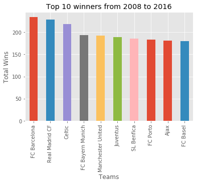

```python
# let's visualize the result
top_10winners_plot = top_10winners.plot.bar();

# Set the x axis label
top_10winners_plot.set_xlabel('Teams');

# Set the y axis label
top_10winners_plot.set_ylabel('Total Wins');

# Set the chart's title
top_10winners_plot.set_title('Top 10 winners from 2008 to 2016');
```

looks like these teams have been dominating their leagues over this 8 seasons period

```python
#Top 10 losers from 2008 to 2016 (excluding the number of draws)
top_10losers = df_Match_sub['loser'].value_counts()[1:11]
top_10losers
```

```
Kilmarnock         142
Getafe CF          139
RCD Espanyol       134
Sunderland         134
St. Mirren         131
Aston Villa        130
Chievo Verona      129
Vitória Setúbal    125
Hannover 96        124
Motherwell         120
Name: loser, dtype: int64
```

### Which league had the most goals scored per season?

```python
#total goals scored in each league from 2008 to 2016
df_Match_sub.groupby('league_name').sum().loc[:, 'home_team_goal':].sort_values(by= 'total_goals',ascending=False)
```

| league_name | home_team_goal | away_team_goal | total_goals |
| --- | --- | --- | --- |
| Spain LIGA BBVA | 4959 | 3453 | 8412 |
| England Premier League | 4715 | 3525 | 8240 |
| Italy Serie A | 4528 | 3367 | 7895 |
| Netherlands Eredivisie | 4357 | 3185 | 7542 |
| France Ligue 1 | 4265 | 3162 | 7427 |
| Germany 1. Bundesliga | 3982 | 3121 | 7103 |
| Portugal Liga ZON Sagres | 2890 | 2311 | 5201 |
| Belgium Jupiler League | 2781 | 2060 | 4841 |
| Scotland Premier League | 2607 | 2197 | 4804 |
| Poland Ekstraklasa | 2678 | 1978 | 4656 |
| Switzerland Super League | 2365 | 1801 | 4166 |

```python
# top total goals scored in a season per league
goals_league = df_Match_sub.groupby(['league_name','season']).total_goals.sum()
goals_league
```

```
league_name               season
Belgium Jupiler League    2008/2009     855
                          2009/2010     565
                          2010/2011     635
                          2011/2012     691
                          2012/2013     703
                          2013/2014      30
                          2014/2015     668
                          2015/2016     694
England Premier League    2008/2009     942
                          2009/2010    1053
                          2010/2011    1063
                          2011/2012    1066
                          2012/2013    1063
                          2013/2014    1052
                          2014/2015     975
                          2015/2016    1026
France Ligue 1            2008/2009     858
                          2009/2010     916
                          2010/2011     890
                          2011/2012     956
                          2012/2013     967
                          2013/2014     933
                          2014/2015     947
                          2015/2016     960
Germany 1. Bundesliga     2008/2009     894
                          2009/2010     866
                          2010/2011     894
                          2011/2012     875
                          2012/2013     898
                          2013/2014     967
                                       ...
Portugal Liga ZON Sagres  2010/2011     584
                          2011/2012     634
                          2012/2013     667
                          2013/2014     569
                          2014/2015     763
                          2015/2016     831
Scotland Premier League   2008/2009     548
                          2009/2010     585
```

[output cut: 8 more lines]

```
                          2010/2011    1042
                          2011/2012    1050
                          2012/2013    1091
                          2013/2014    1045
                          2014/2015    1009
                          2015/2016    1043
Switzerland Super League  2008/2009     540
                          2009/2010     599
                          2010/2011     537
                          2011/2012     425
                          2012/2013     462
                          2013/2014     520
                          2014/2015     517
                          2015/2016     566
Name: total_goals, Length: 88, dtype: int64
```

```python
#let's get the average total goals scored
league_mean = goals_league.groupby(['league_name']).mean().sort_values(ascending=False)
league_mean
```

```
league_name
Spain LIGA BBVA             1051.500
England Premier League      1030.000
Italy Serie A                986.875
Netherlands Eredivisie       942.750
France Ligue 1               928.375
Germany 1. Bundesliga        887.875
Portugal Liga ZON Sagres     650.125
Belgium Jupiler League       605.125
Scotland Premier League      600.500
Poland Ekstraklasa           582.000
Switzerland Super League     520.750
Name: total_goals, dtype: float64
```

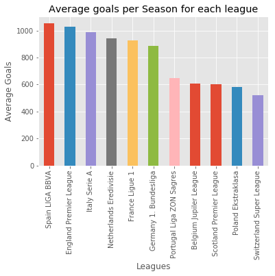

```python
# let's visualize the result
league_mean_plot = league_mean.plot.bar();

# Set the x axis label
league_mean_plot.set_xlabel('Leagues');

# Set the y axis label
league_mean_plot.set_ylabel('Average Goals');

# Set the chart's title
league_mean_plot.set_title('Average goals per Season for each league');
```

Looks like Spain LIGA BBVA has the most goals on average in the selected time period, so if you fancy more goals you should totally watch this league!

### Is there any advantage in playing matches at home?

```python
# total matches won at home per league during the whole period (2008-2016)
total_home_wins = df_Match_sub.query('home_team_goal > away_team_goal').groupby(['league_name'])['home_team_name'].count()
total_home_wins
```

```
league_name
Belgium Jupiler League       810
England Premier League      1390
France Ligue 1              1359
Germany 1. Bundesliga       1107
Italy Serie A               1407
Netherlands Eredivisie      1171
Poland Ekstraklasa           870
Portugal Liga ZON Sagres     908
Scotland Premier League      760
Spain LIGA BBVA             1485
Switzerland Super League     650
Name: home_team_name, dtype: int64
```

```python
# total matches won away per league during the whole period (2008-2016)
total_away_wins = df_Match_sub.query('home_team_goal < away_team_goal').groupby(['league_name'])['away_team_name'].count()
total_away_wins
```

```
league_name
Belgium Jupiler League      493
England Premier League      867
France Ligue 1              822
Germany 1. Bundesliga       744
Italy Serie A               814
Netherlands Eredivisie      696
Poland Ekstraklasa          525
Portugal Liga ZON Sagres    611
Scotland Premier League     617
Spain LIGA BBVA             851
Switzerland Super League    426
Name: away_team_name, dtype: int64
```

```python
# total matches ended in a draw per league during the whole period (2008-2016)
total_draws = df_Match_sub.query('winner == "Draw"').groupby(['league_name'])['away_team_name'].count()
total_draws
```

```
league_name
Belgium Jupiler League      425
England Premier League      783
France Ligue 1              859
Germany 1. Bundesliga       597
Italy Serie A               796
Netherlands Eredivisie      581
Poland Ekstraklasa          525
Portugal Liga ZON Sagres    533
Scotland Premier League     447
Spain LIGA BBVA             704
Switzerland Super League    346
Name: away_team_name, dtype: int64
```

```python
#indexing for the plot
ind = np.arange(len(total_away_wins.index))
width = 0.35       # the width of the bars
```

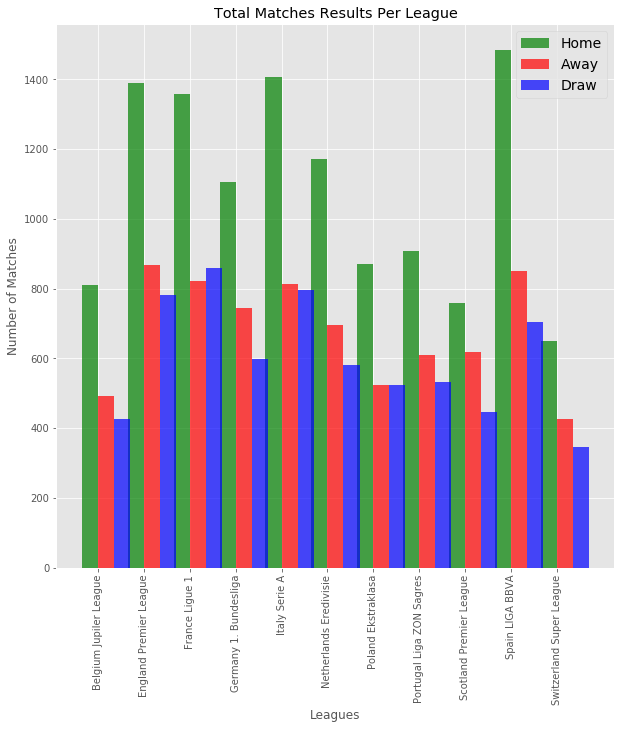

```python
# plot bars
plt.figure (figsize=(10,10))
green_bars = plt.bar(ind, total_home_wins, width, color='green', alpha=.7, label='Home')
red_bars = plt.bar(ind + width, total_away_wins, width, color='red', alpha=.7, label='Away')
blue_bars = plt.bar(ind + 2*width, total_draws, width, color='blue', alpha=.7, label='Draw')
# title and labels
plt.ylabel('Number of Matches')
plt.xlabel('Leagues')
plt.title('Total Matches Results Per League')
locations = ind + width / 2
labels = total_away_wins.index
plt.xticks(locations, labels)
plt.xticks(rotation='vertical')
# legend
plt.legend(prop = {"size" : 14});
```

We see here that there a good advantage in playing at home, specially in spain, Italy and England.

### which teams are the top performers at home and in away matches?

```python
#Top 10 winners at home from 2008 to 2016
top_home10 = df_Match_sub.query('home_team_goal >away_team_goal')['home_team_name'].value_counts()[0:10]
top_home10
```

```
FC Barcelona         131
Real Madrid CF       129
Celtic               120
Manchester United    116
Manchester City      113
FC Bayern Munich     109
PSV                  105
Juventus             105
Ajax                 103
Atlético Madrid      103
Name: home_team_name, dtype: int64
```

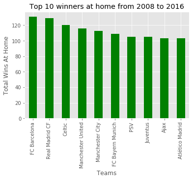

```python
# let's visualize the result
top_home10_plot = top_home10.plot.bar(color = "green");

# Set the x axis label
top_home10_plot.set_xlabel('Teams');

# Set the y axis label
top_home10_plot.set_ylabel('Total Wins At Home');

# Set the chart's title
top_home10_plot.set_title('Top 10 winners at home from 2008 to 2016');
```

```python
#Top 10 winners away from 2008 to 2016
top_away10 = df_Match_sub.query('home_team_goal < away_team_goal')['away_team_name'].value_counts()[0:10]
top_away10
```

```
FC Barcelona         103
Real Madrid CF        99
Celtic                98
Juventus              84
FC Bayern Munich      84
SL Benfica            83
FC Porto              81
Ajax                  78
FC Basel              77
Manchester United     76
Name: away_team_name, dtype: int64
```

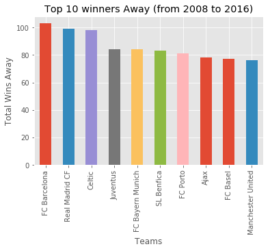

```python
# let's visualize the result
top_away10_plot = top_away10.plot.bar();

# Set the x axis label
top_away10_plot.set_xlabel('Teams');

# Set the y axis label
top_away10_plot.set_ylabel('Total Wins Away');

# Set the chart's title
top_away10_plot.set_title('Top 10 winners Away (from 2008 to 2016)');
```

### Which teams had the most wins in a single season?

```python
#Top 10 teams that won the most matches in a single season from 2008 to 2016
Top_10_wins = df_Match_sub.loc[df_Match_sub['winner'] != 'Draw'].groupby(['season']).winner.value_counts().sort_values(ascending=False)[0:10]
Top_10_wins
```

```
season     winner
2013/2014  Juventus               33
2012/2013  FC Barcelona           32
2011/2012  Real Madrid CF         32
2013/2014  Celtic                 31
2009/2010  FC Barcelona           31
           Real Madrid CF         31
2010/2011  Rangers                30
           FC Barcelona           30
2015/2016  Paris Saint-Germain    30
2011/2012  Celtic                 30
Name: winner, dtype: int64
```

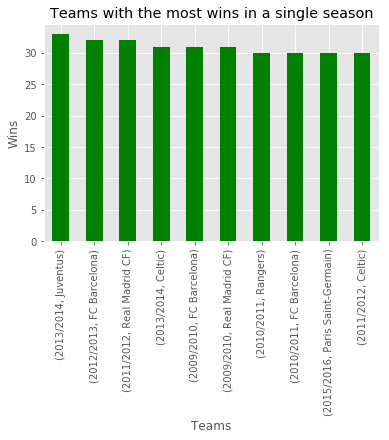

```python
# let's visualize the result
Top_10_wins_plot = Top_10_wins.plot.bar(color = 'green');

# Set the x axis label
Top_10_wins_plot.set_xlabel('Teams');

# Set the y axis label
Top_10_wins_plot.set_ylabel('Wins');

# Set the chart's title
Top_10_wins_plot.set_title('Teams with the most wins in a single season');
```

### Which teams improved the most over the time period?

We'll try to analyse this based on winning and losing throughout the season, we'll take the average of the first 2 seasons and the last 2, and then compare it with each other for every team.

```python
# lets get the number of wins and losses for each team each season

wins = df_Match_sub.loc[df_Match_sub['winner'] != 'Draw'].groupby(['season']).winner.value_counts()

loss = df_Match_sub.loc[df_Match_sub['loser'] != 'Draw'].groupby(['season']).loser.value_counts()

df = pd.concat([wins, loss], axis=1)
df.columns = ['wins','losses']

df
```

|  |  | wins | losses |
| --- | --- | --- | --- |
| 2008/2009 | 1. FC Köln | 11 | 17.0 |
|  | AC Bellinzona | 11 | 15.0 |
|  | ADO Den Haag | 8 | 18.0 |
|  | AJ Auxerre | 16 | 15.0 |
|  | AS Monaco | 11 | 15.0 |
|  | AS Nancy-Lorraine | 10 | 16.0 |
|  | AS Saint-Étienne | 11 | 20.0 |
|  | AZ | 25 | 4.0 |
|  | Aberdeen | 14 | 13.0 |
|  | Académica de Coimbra | 10 | 11.0 |
|  | Ajax | 21 | 8.0 |
|  | Amadora | 8 | 12.0 |
|  | Arka Gdynia | 7 | 14.0 |
|  | Arsenal | 20 | 6.0 |
|  | Aston Villa | 17 | 10.0 |
|  | Atalanta | 13 | 17.0 |
|  | Athletic Club de Bilbao | 12 | 18.0 |
|  | Atlético Madrid | 20 | 11.0 |
|  | BSC Young Boys | 22 | 7.0 |
|  | Bayer 04 Leverkusen | 14 | 13.0 |
|  | Beerschot AC | 11 | 14.0 |
|  | Blackburn Rovers | 10 | 17.0 |
|  | Bologna | 9 | 19.0 |
|  | Bolton Wanderers | 11 | 19.0 |
|  | Borussia Dortmund | 15 | 5.0 |
|  | Borussia Mönchengladbach | 8 | 19.0 |
|  | CA Osasuna | 10 | 15.0 |
|  | CD Nacional | 15 | 8.0 |
|  | CD Numancia | 10 | 23.0 |
|  | CF Os Belenenses | 5 | 16.0 |
| ... | ... | ... | ... |
| 2015/2016 | Stade Rennais FC | 13 | 12.0 |
|  | Stade de Reims | 10 | 19.0 |
|  | Standard de Liège | 12 | 13.0 |
|  | Stoke City | 14 | 15.0 |
|  | Sunderland | 9 | 17.0 |
|  | Swansea City | 12 | 15.0 |
|  | TSG 1899 Hoffenheim | 9 | 15.0 |
|  | Termalica Bruk-Bet Nieciecza | 8 | 13.0 |
|  | Tondela | 8 | 20.0 |
|  | Torino | 12 | 17.0 |
|  | Tottenham Hotspur | 19 | 6.0 |
|  | Toulouse FC | 9 | 16.0 |
|  | UD Las Palmas | 12 | 18.0 |
|  | Udinese | 10 | 19.0 |
|  | Uniao da Madeira | 7 | 19.0 |
|  | Valencia CF | 11 | 16.0 |
|  | VfB Stuttgart | 9 | 19.0 |
|  | VfL Wolfsburg | 12 | 13.0 |
|  | Villarreal CF | 18 | 10.0 |
|  | Vitesse | 12 | 12.0 |
|  | Vitória Guimarães | 9 | 12.0 |
|  | Vitória Setúbal | 6 | 16.0 |
|  | Waasland-Beveren | 9 | 15.0 |
|  | Watford | 12 | 17.0 |
|  | West Bromwich Albion | 10 | 15.0 |
|  | West Ham United | 16 | 8.0 |
|  | Willem II | 6 | 17.0 |
|  | Wisła Kraków | 8 | 9.0 |
|  | Zagłębie Lubin | 12 | 9.0 |
|  | Śląsk Wrocław | 8 | 12.0 |

1478 rows × 2 columns

```python
# check missing values
df[df['losses'].isnull()]
```

|  |  | wins | losses |
| --- | --- | --- | --- |
| 2010/2011 | FC Porto | 27 | NaN |
| 2011/2012 | Juventus | 22 | NaN |
| 2012/2013 | FC Porto | 24 | NaN |
| 2013/2014 | KV Oostende | 4 | NaN |

```python
#missing values because these teams didn't lose any games, so let's fill it with 0
df.fillna(0,inplace = True)
```

```python
# Checking missing values
df.isnull().any(axis=1).sum()
```

```
0
```

```python
# let's add a column and call it score, it's the difference of total wins and total losses
df["score"]= (df["wins"] - df["losses"]).astype(int)
```

```python
# Display df
df.head()
```

|  |  | wins | losses | score |
| --- | --- | --- | --- | --- |
| 2008/2009 | 1. FC Köln | 11 | 17.0 | -6 |
|  | AC Bellinzona | 11 | 15.0 | -4 |
|  | ADO Den Haag | 8 | 18.0 | -10 |
|  | AJ Auxerre | 16 | 15.0 | 1 |
|  | AS Monaco | 11 | 15.0 | -4 |

```python
#lets take the average score between the first two seasons in the dataset and compare with the last two seasons we'll call it final_score
final_score = (df.score['2015/2016'] + df.score['2014/2015'])/2 - (df.score['2008/2009'] + df.score['2009/2010'])/2 #- df.score['2013/2014'] - df.score['2012/2013'] - df.score['2011/2012'] - df.score['2010/2011'] - df.score['2009/2010'] - df.score['2008/2009']
final_score.dropna(inplace=True)
```

```python
# Top 10 teams which improved the most
final_score.sort_values(ascending=False)[:10]
```

```
Paris Saint-Germain         22.5
Atlético Madrid             17.0
Borussia Mönchengladbach    16.5
AS Saint-Étienne            16.0
Juventus                    15.5
Aberdeen                    15.5
Piast Gliwice               12.5
Napoli                      12.5
AS Monaco                   12.5
Sporting CP                 12.0
Name: score, dtype: float64
```

```python
# Top 10 teams which got worse
final_score.sort_values(ascending=False)[-10:]
```

```
FC Zürich                -11.5
Manchester United        -11.5
Olympique de Marseille   -12.0
Dundee United            -12.0
Hamburger SV             -12.5
Wisła Kraków             -13.5
Inter                    -14.5
VfB Stuttgart            -17.0
FC Twente                -20.5
Aston Villa              -25.0
Name: score, dtype: float64
```

```python
# worst and top performers
top_performers = final_score[final_score > 0]
worst_performers = final_score[final_score <= 0]
```

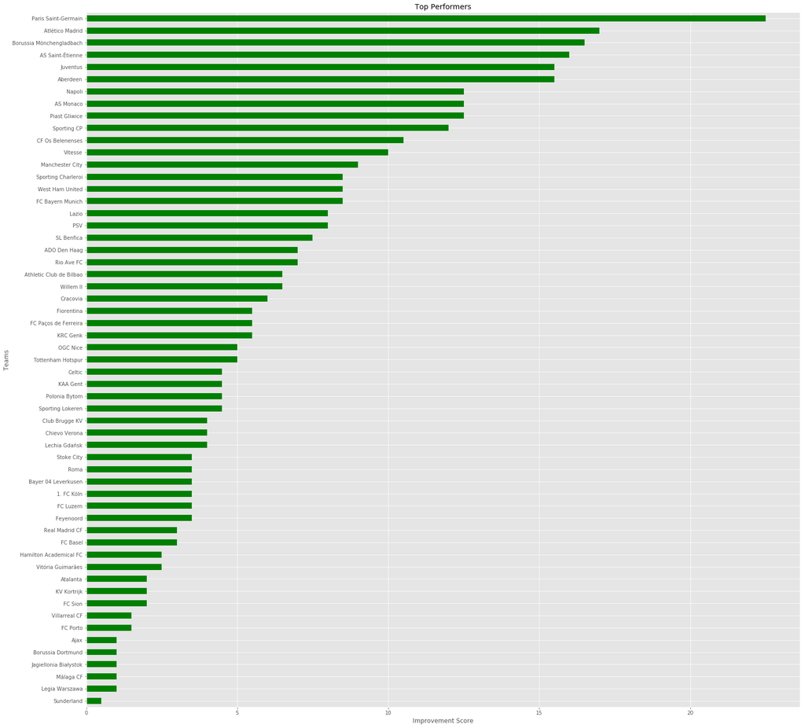

```python
# let's visualize the top performers:
top_performers_plot = top_performers.sort_values(ascending=True).plot.barh(figsize=(25, 25),color = "green");
# Set the x axis label
top_performers_plot.set_xlabel('Improvement Score');
# Set the y axis label
top_performers_plot.set_ylabel('Teams');
# Set the chart's title
top_performers_plot.set_title('Top Performers');
```

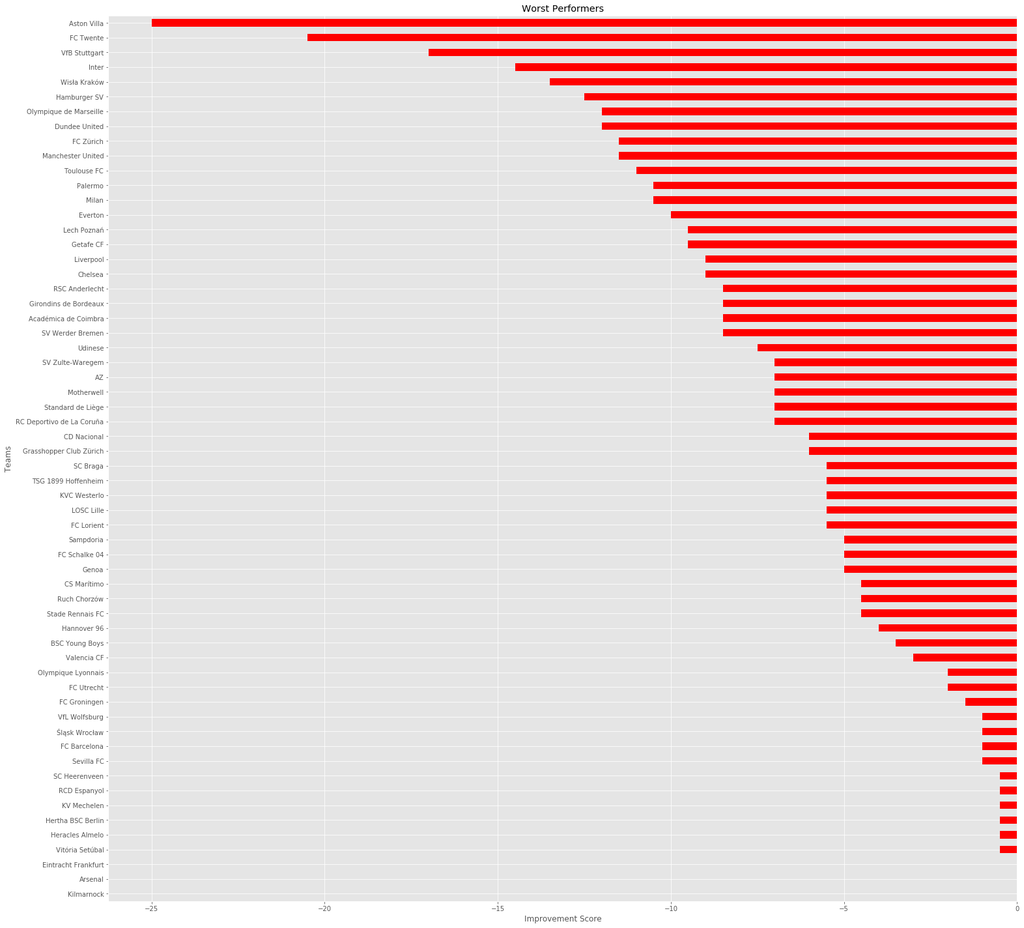

```python
# let's visualize the worst performers:
worst_performers_plot = worst_performers.sort_values(ascending=False).plot.barh(figsize=(25, 25),color = "red");

# Set the x axis label
worst_performers_plot.set_xlabel('Improvement Score');

# Set the y axis label
worst_performers_plot.set_ylabel('Teams');

# Set the chart's title
worst_performers_plot.set_title('Worst Performers');
```

### What are the attributes of the top teams?

```python
# let's recall our df created earlier, it hass the top teams in each season:
# for example, top 10 teams that won more than they lost (score = wins - losses) in 2008/2009 season:
df.score['2008/2009'][:10]
```

```
1. FC Köln              -6
AC Bellinzona           -4
ADO Den Haag           -10
AJ Auxerre               1
AS Monaco               -4
AS Nancy-Lorraine       -6
AS Saint-Étienne        -9
AZ                      21
Aberdeen                 1
Académica de Coimbra    -1
Name: score, dtype: int64
```

```python
# list of top 10 teams in 2008/2009
list(df.score['2008/2009'][:10].index)
```

```
['1. FC Köln',
 'AC Bellinzona',
 'ADO Den Haag',
 'AJ Auxerre',
 'AS Monaco',
 'AS Nancy-Lorraine',
 'AS Saint-Étienne',
 'AZ',
 'Aberdeen',
 'Académica de Coimbra']
```

```python
# let's start  with 2011 (end of 2010/2011 season)
top_attributes = df_Team[df_Team["team_long_name"].isin(df.score['2010/2011'][:10].index) & (df_Team['date'].dt.year == 2011) ]
top_attributes
```

|  | id_x | team_api_id | team_long_name | team_short_name | date | buildUpPlaySpeed | buildUpPlaySpeedClass | buildUpPlayDribblingClass | buildUpPlayPassing | buildUpPlayPassingClass | ... | chanceCreationShooting | chanceCreationShootingClass | chanceCreationPositioningClass | defencePressure | defencePressureClass | defenceAggression | defenceAggressionClass | defenceTeamWidth | defenceTeamWidthClass | defenceDefenderLineClass |
| --- | --- | --- | --- | --- | --- | --- | --- | --- | --- | --- | --- | --- | --- | --- | --- | --- | --- | --- | --- | --- | --- |
| 302 | 9537 | 8583 | AJ Auxerre | AUX | 2011-02-22 | 35 | Balanced | Little | 65 | Mixed | ... | 50 | Normal | Organised | 35 | Medium | 45 | Press | 65 | Normal | Cover |
| 360 | 9547 | 9829 | AS Monaco | MON | 2011-02-22 | 65 | Balanced | Little | 50 | Mixed | ... | 50 | Normal | Organised | 35 | Medium | 55 | Press | 50 | Normal | Cover |
| 372 | 9549 | 8481 | AS Nancy-Lorraine | NAN | 2011-02-22 | 35 | Balanced | Little | 35 | Mixed | ... | 35 | Normal | Organised | 35 | Medium | 55 | Press | 50 | Normal | Cover |
| 431 | 11074 | 108893 | AC Arles-Avignon | ARL | 2011-02-22 | 50 | Balanced | Little | 65 | Mixed | ... | 35 | Normal | Organised | 25 | Deep | 45 | Press | 35 | Normal | Cover |
| 535 | 15624 | 8722 | 1. FC Köln | FCK | 2011-02-22 | 58 | Balanced | Little | 71 | Long | ... | 50 | Normal | Organised | 40 | Medium | 40 | Press | 56 | Normal | Cover |
| 602 | 16239 | 8165 | 1. FC Nürnberg | NUR | 2011-02-22 | 45 | Balanced | Little | 50 | Mixed | ... | 56 | Normal | Organised | 55 | Medium | 61 | Press | 46 | Normal | Cover |
| 608 | 16243 | 9905 | 1. FSV Mainz 05 | MAI | 2011-02-22 | 65 | Balanced | Little | 50 | Mixed | ... | 53 | Normal | Organised | 57 | Medium | 53 | Press | 43 | Normal | Cover |
| 614 | 16848 | 8350 | 1. FC Kaiserslautern | KAI | 2011-02-22 | 48 | Balanced | Little | 42 | Mixed | ... | 53 | Normal | Organised | 38 | Medium | 48 | Press | 53 | Normal | Cover |
| 900 | 26560 | 10217 | ADO Den Haag | HAA | 2011-02-22 | 53 | Balanced | Little | 53 | Mixed | ... | 66 | Normal | Organised | 46 | Medium | 62 | Press | 65 | Normal | Cover |
| 1403 | 49116 | 6493 | AC Bellinzona | BEL | 2011-02-22 | 47 | Balanced | Little | 54 | Mixed | ... | 55 | Normal | Organised | 32 | Deep | 50 | Press | 56 | Normal | Cover |

10 rows × 25 columns

```python
# let's see the date of our data in df_Team to know at which year these data were collected.
dates_available = list(df_Team['date'].dt.year.unique())
dates_available
```

```
[2010, 2011, 2012, 2013, 2014, 2015]
```

```python
# let's see the date of our data in df_Team to know at which year these data were collected.
# we are interested in values from 2012 and above since we already processed 2010 and 2011
dates_available = list(df_Team['date'].dt.year.unique())[2:]
seasons_ = ['2011/2012','2012/2013','2013/2014','2014/2015']
dates_available,seasons_
```

```
([2012, 2013, 2014, 2015],
 ['2011/2012', '2012/2013', '2013/2014', '2014/2015'])
```

```python
# and we put the data together
for i in range(len(seasons_)):
    top_attributes_i =  df_Team[df_Team["team_long_name"].isin(df.score[seasons_[i]][:10].index) & (df_Team['date'].dt.year == dates_available[i]) ]
#     top_attributes=pd.concat([top_attributes, df_Team[df_Team["team_long_name"].isin(df.score[seasons_[i]][:10].index) & (df_Team['date'].dt.year == dates_available[i])]]
    top_attributes = pd.concat([top_attributes, top_attributes_i])
```

```python
# let's make a copy so we can drop uneccessary columns
top_attributes = top_attributes.copy()
```

```python
# Display top_attributes
top_attributes.head()
```

|  | id_x | team_api_id | team_long_name | team_short_name | date | buildUpPlaySpeed | buildUpPlaySpeedClass | buildUpPlayDribblingClass | buildUpPlayPassing | buildUpPlayPassingClass | ... | chanceCreationShooting | chanceCreationShootingClass | chanceCreationPositioningClass | defencePressure | defencePressureClass | defenceAggression | defenceAggressionClass | defenceTeamWidth | defenceTeamWidthClass | defenceDefenderLineClass |
| --- | --- | --- | --- | --- | --- | --- | --- | --- | --- | --- | --- | --- | --- | --- | --- | --- | --- | --- | --- | --- | --- |
| 302 | 9537 | 8583 | AJ Auxerre | AUX | 2011-02-22 | 35 | Balanced | Little | 65 | Mixed | ... | 50 | Normal | Organised | 35 | Medium | 45 | Press | 65 | Normal | Cover |
| 360 | 9547 | 9829 | AS Monaco | MON | 2011-02-22 | 65 | Balanced | Little | 50 | Mixed | ... | 50 | Normal | Organised | 35 | Medium | 55 | Press | 50 | Normal | Cover |
| 372 | 9549 | 8481 | AS Nancy-Lorraine | NAN | 2011-02-22 | 35 | Balanced | Little | 35 | Mixed | ... | 35 | Normal | Organised | 35 | Medium | 55 | Press | 50 | Normal | Cover |
| 431 | 11074 | 108893 | AC Arles-Avignon | ARL | 2011-02-22 | 50 | Balanced | Little | 65 | Mixed | ... | 35 | Normal | Organised | 25 | Deep | 45 | Press | 35 | Normal | Cover |
| 535 | 15624 | 8722 | 1. FC Köln | FCK | 2011-02-22 | 58 | Balanced | Little | 71 | Long | ... | 50 | Normal | Organised | 40 | Medium | 40 | Press | 56 | Normal | Cover |

5 rows × 25 columns

```python
# We can drop the first columns
top_attributes.drop(["id_x", "team_api_id","team_short_name",'date'], axis=1, inplace= True)
```

```python
# Display top_attributes information
top_attributes.info()
```

```
<class 'pandas.core.frame.DataFrame'>
Int64Index: 50 entries, 302 to 1168
Data columns (total 21 columns):
team_long_name                    50 non-null object
buildUpPlaySpeed                  50 non-null int64
buildUpPlaySpeedClass             50 non-null object
buildUpPlayDribblingClass         50 non-null object
buildUpPlayPassing                50 non-null int64
buildUpPlayPassingClass           50 non-null object
buildUpPlayPositioningClass       50 non-null object
chanceCreationPassing             50 non-null int64
chanceCreationPassingClass        50 non-null object
chanceCreationCrossing            50 non-null int64
chanceCreationCrossingClass       50 non-null object
chanceCreationShooting            50 non-null int64
chanceCreationShootingClass       50 non-null object
chanceCreationPositioningClass    50 non-null object
defencePressure                   50 non-null int64
defencePressureClass              50 non-null object
defenceAggression                 50 non-null int64
defenceAggressionClass            50 non-null object
defenceTeamWidth                  50 non-null int64
defenceTeamWidthClass             50 non-null object
defenceDefenderLineClass          50 non-null object
dtypes: int64(8), object(13)
memory usage: 8.6+ KB
```

```python
# get some stats about the dataframe
top_attributes.describe().T
```

|  | count | mean | std | min | 25% | 50% | 75% | max |
| --- | --- | --- | --- | --- | --- | --- | --- | --- |
| buildUpPlaySpeed | 50.0 | 52.06 | 9.212702 | 35.0 | 46.0 | 52.0 | 59.00 | 68.0 |
| buildUpPlayPassing | 50.0 | 49.60 | 9.019254 | 30.0 | 44.0 | 50.0 | 53.00 | 71.0 |
| chanceCreationPassing | 50.0 | 50.74 | 8.171154 | 28.0 | 48.0 | 51.5 | 55.00 | 67.0 |
| chanceCreationCrossing | 50.0 | 50.46 | 10.244381 | 34.0 | 41.0 | 52.0 | 56.00 | 72.0 |
| chanceCreationShooting | 50.0 | 51.38 | 9.862090 | 23.0 | 46.0 | 52.0 | 56.75 | 71.0 |
| defencePressure | 50.0 | 44.84 | 9.643354 | 25.0 | 38.0 | 43.0 | 51.00 | 68.0 |
| defenceAggression | 50.0 | 51.16 | 8.562758 | 34.0 | 45.0 | 50.0 | 58.00 | 65.0 |
| defenceTeamWidth | 50.0 | 53.24 | 6.891462 | 35.0 | 50.0 | 52.5 | 59.00 | 67.0 |

Now we have 50 teams (or a data collected for the same team in a different date) since teams change their style, it's not a duplicate.

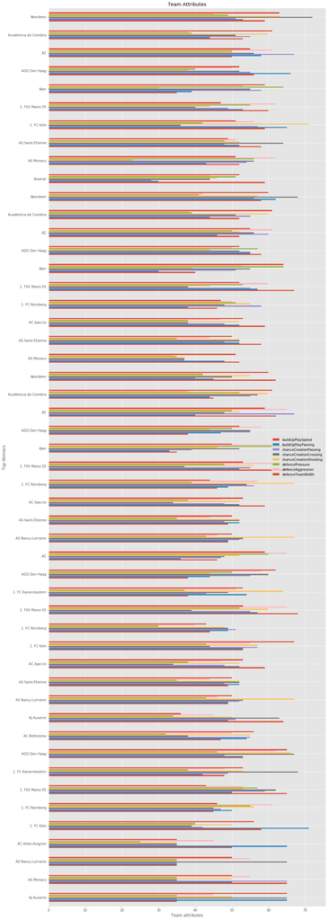

```python
#let's make a visualization
fig, ax = plt.subplots(figsize=(15, 50))

# create a new bar chart
ax = top_attributes.plot.barh(ax=ax);

ax.set_yticklabels(top_attributes['team_long_name'])

# Set the y axis label
ax.set_ylabel('Top Winners')

# Set the x axis label
plt.xlabel("Team attributes")

# Set the chart's title
ax.set_title('Team Attributes')


plt.show();
```

Now we visualize the categorical data, best way to do that is with pie charts.

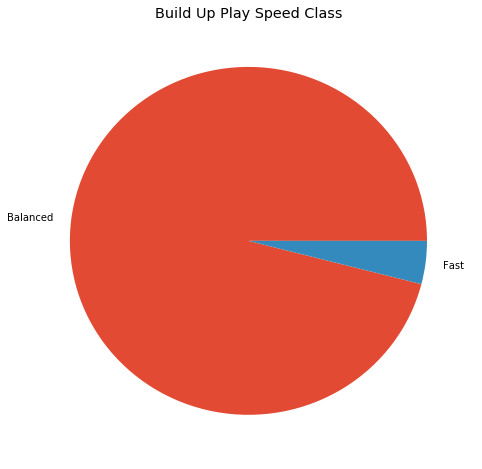

```python
# plot a pie chart and set it's title accordingly
top_attributes.buildUpPlaySpeedClass.value_counts().plot.pie(figsize=(8, 8)).set_title('Build Up Play Speed Class');
plt.ylabel("");
```

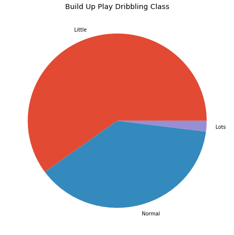

```python
# plot a pie chart and set it's title accordingly
top_attributes.buildUpPlayDribblingClass.value_counts().plot.pie(figsize=(8, 8)).set_title('Build Up Play Dribbling Class');
plt.ylabel("");
```

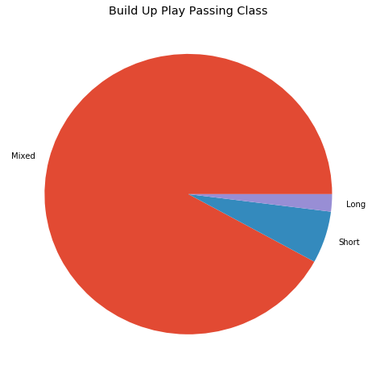

```python
# plot a pie chart and set it's title accordingly
top_attributes.buildUpPlayPassingClass.value_counts().plot.pie(figsize=(8, 8)).set_title('Build Up Play Passing Class');
plt.ylabel("");
```

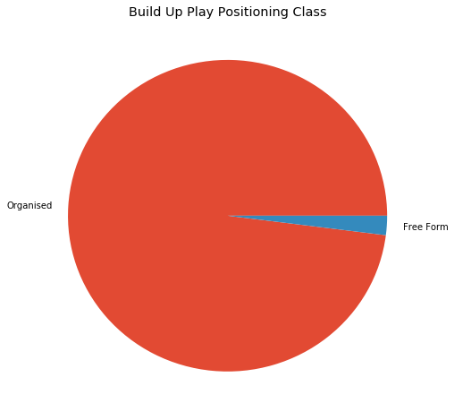

```python
# plot a pie chart and set it's title accordingly
top_attributes.buildUpPlayPositioningClass.value_counts().plot.pie(figsize=(8, 8)).set_title('Build Up Play Positioning Class');
plt.ylabel("");
```

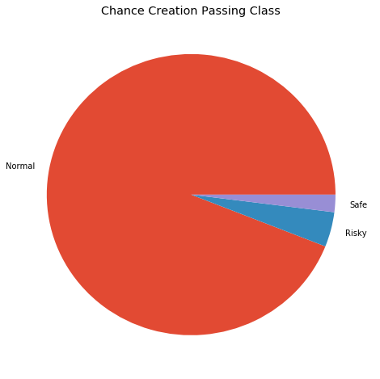

```python
# plot a pie chart and set it's title accordingly
top_attributes.chanceCreationPassingClass.value_counts().plot.pie(figsize=(8, 8)).set_title('Chance Creation Passing Class');
plt.ylabel("");
```

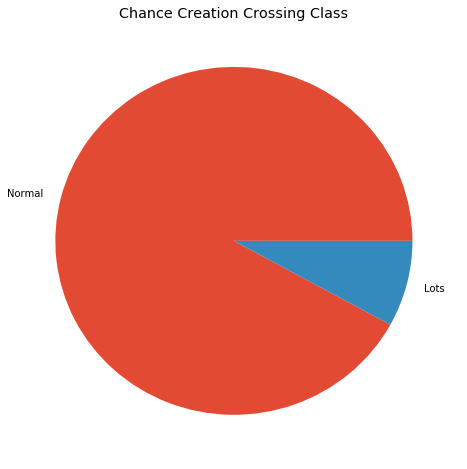

```python
# plot a pie chart and set it's title accordingly
top_attributes.chanceCreationCrossingClass.value_counts().plot.pie(figsize=(8, 8)).set_title('Chance Creation Crossing Class');
plt.ylabel("");
```

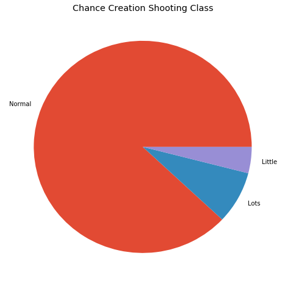

```python
# plot a pie chart and set it's title accordingly
top_attributes.chanceCreationShootingClass.value_counts().plot.pie(figsize=(8, 8)).set_title('Chance Creation Shooting Class');
plt.ylabel("");
```

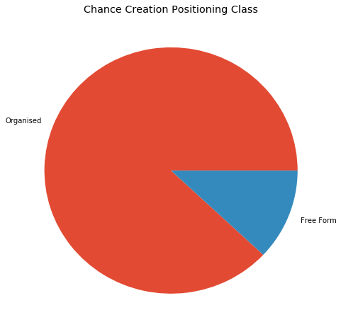

```python
# plot a pie chart and set it's title accordingly
top_attributes.chanceCreationPositioningClass.value_counts().plot.pie(figsize=(8, 8)).set_title('Chance Creation Positioning Class');
plt.ylabel("");
```

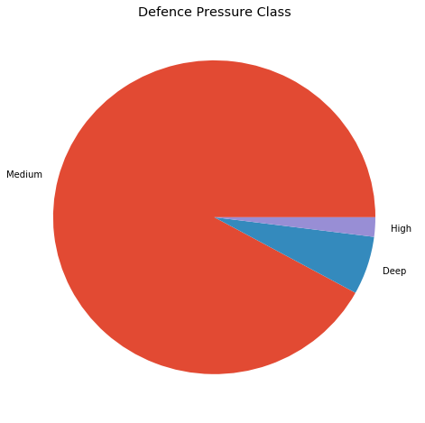

```python
# plot a pie chart and set it's title accordingly
top_attributes.defencePressureClass.value_counts().plot.pie(figsize=(8, 8)).set_title('Defence Pressure Class');
plt.ylabel("");
```

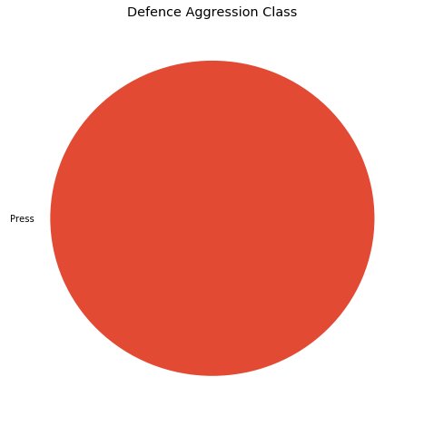

```python
# plot a pie chart and set it's title accordingly
top_attributes.defenceAggressionClass.value_counts().plot.pie(figsize=(8, 8)).set_title('Defence Aggression Class');
plt.ylabel("");
```

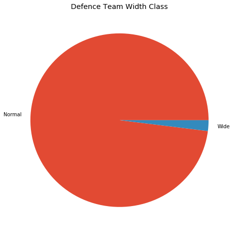

```python
# plot a pie chart and set it's title accordingly
top_attributes.defenceTeamWidthClass.value_counts().plot.pie(figsize=(8, 8)).set_title('Defence Team Width Class');
plt.ylabel("");
```

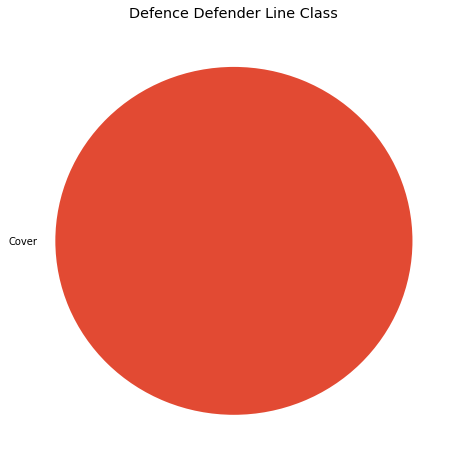

```python
# plot a pie chart and set it's title accordingly
top_attributes.defenceDefenderLineClass.value_counts().plot.pie(figsize=(8, 8)).set_title('Defence Defender Line Class');
plt.ylabel("");
```

```python
top_attributes.defenceDefenderLineClass.value_counts()
```

```
Cover    50
Name: defenceDefenderLineClass, dtype: int64
```

### what are the attributes of the top players in 2016? and Does age play a factor in that?

```python
# We can add age column first to df_Player_Attributes
df_Player_Attributes['age'] = (df_Player_Attributes.date - df_Player_Attributes.birthday)/ np.timedelta64(1, 'Y')
```

```python
# To get the top players we group by player name because each player has more than one instance, and we pick the highest value found with max than we sort by overall rating, then we choose to show only the first 50
top_50 = df_Player_Attributes.groupby('player_name').max().sort_values(by = 'overall_rating', ascending = False)[:50]
```

```python
# we select only the relevant columns, we don't want to plot ids and visualize them
top_50= top_50.loc[:,'overall_rating':]
```

```python
# Display top_50 dataframe
top_50.head()
```

| player_name | overall_rating | potential | preferred_foot | attacking_work_rate | defensive_work_rate | crossing | finishing | heading_accuracy | short_passing | volleys | ... | sliding_tackle | gk_diving | gk_handling | gk_kicking | gk_positioning | gk_reflexes | birthday | height | weight | age |
| --- | --- | --- | --- | --- | --- | --- | --- | --- | --- | --- | --- | --- | --- | --- | --- | --- | --- | --- | --- | --- | --- |
| Lionel Messi | 94.0 | 97.0 | left | medium | medium | 85.0 | 97.0 | 73.0 | 90.0 | 91.0 | ... | 21.0 | 8.0 | 20.0 | 79.0 | 20.0 | 20.0 | 1987-06-24 | 170.18 | 159 | 28.482447 |
| Cristiano Ronaldo | 93.0 | 95.0 | right | high | low | 89.0 | 95.0 | 88.0 | 84.0 | 87.0 | ... | 23.0 | 9.0 | 21.0 | 73.0 | 21.0 | 21.0 | 1985-02-05 | 185.42 | 176 | 30.691938 |
| Gianluigi Buffon | 93.0 | 93.0 | right | medium | medium | 25.0 | 25.0 | 33.0 | 45.0 | 28.0 | ... | 26.0 | 91.0 | 93.0 | 82.0 | 96.0 | 93.0 | 1978-01-28 | 193.04 | 201 | 38.191065 |
| Wayne Rooney | 93.0 | 93.0 | right | medium | high | 81.0 | 94.0 | 85.0 | 88.0 | 89.0 | ... | 41.0 | 11.0 | 21.0 | 86.0 | 21.0 | 21.0 | 1985-10-24 | 175.26 | 183 | 30.357913 |
| Gregory Coupet | 92.0 | 93.0 | right | y | es | 21.0 | 21.0 | 21.0 | 28.0 | 14.0 | ... | 12.0 | 93.0 | 91.0 | 82.0 | 93.0 | 88.0 | 1972-12-31 | 180.34 | 176 | 38.144520 |

5 rows × 42 columns

Let's see their attributes:

```python
# get statistics on the top 50 players
top_50.describe()
```

|  | overall_rating | potential | crossing | finishing | heading_accuracy | short_passing | volleys | dribbling | curve | free_kick_accuracy | ... | standing_tackle | sliding_tackle | gk_diving | gk_handling | gk_kicking | gk_positioning | gk_reflexes | height | weight | age |
| --- | --- | --- | --- | --- | --- | --- | --- | --- | --- | --- | --- | --- | --- | --- | --- | --- | --- | --- | --- | --- | --- |
| count | 50.000000 | 50.000000 | 50.000000 | 50.000000 | 50.000000 | 50.00000 | 50.000000 | 50.000000 | 50.00000 | 50.000000 | ... | 50.000000 | 50.00000 | 50.000000 | 50.000000 | 50.000000 | 50.000000 | 50.000000 | 50.000000 | 50.000000 | 50.000000 |
| mean | 89.700000 | 91.740000 | 69.660000 | 71.100000 | 71.500000 | 78.92000 | 69.460000 | 75.780000 | 68.74000 | 83.380000 | ... | 55.540000 | 46.78000 | 24.360000 | 32.640000 | 75.800000 | 33.220000 | 33.300000 | 182.880000 | 176.420000 | 33.749249 |
| std | 1.528638 | 1.562442 | 22.683816 | 25.939687 | 20.738656 | 18.57345 | 23.312614 | 23.658532 | 22.84715 | 8.891385 | ... | 26.912716 | 26.55936 | 28.883835 | 24.350133 | 12.621653 | 25.338758 | 25.304069 | 7.782419 | 16.228081 | 3.994658 |
| min | 88.000000 | 89.000000 | 21.000000 | 21.000000 | 21.000000 | 21.00000 | 14.000000 | 21.000000 | 10.00000 | 45.000000 | ... | 21.000000 | 12.00000 | 7.000000 | 20.000000 | 37.000000 | 20.000000 | 20.000000 | 170.180000 | 148.000000 | 23.997755 |
| 25% | 89.000000 | 91.000000 | 62.250000 | 47.500000 | 65.000000 | 77.25000 | 55.500000 | 64.250000 | 53.25000 | 80.000000 | ... | 28.500000 | 25.00000 | 10.250000 | 21.000000 | 70.000000 | 21.000000 | 21.000000 | 177.800000 | 163.000000 | 30.767914 |
| 50% | 89.000000 | 92.000000 | 78.000000 | 83.000000 | 74.500000 | 84.50000 | 80.500000 | 87.000000 | 79.50000 | 85.000000 | ... | 48.500000 | 32.00000 | 12.500000 | 22.000000 | 77.500000 | 22.000000 | 22.000000 | 182.880000 | 176.000000 | 34.575659 |
| 75% | 90.000000 | 92.750000 | 87.000000 | 91.000000 | 88.750000 | 90.00000 | 87.000000 | 92.000000 | 85.75000 | 89.000000 | ... | 84.000000 | 72.50000 | 15.000000 | 25.000000 | 84.000000 | 25.000000 | 25.000000 | 187.960000 | 187.000000 | 36.473028 |
| max | 94.000000 | 97.000000 | 94.000000 | 97.000000 | 95.000000 | 97.00000 | 93.000000 | 97.000000 | 91.00000 | 94.000000 | ... | 95.000000 | 92.00000 | 94.000000 | 93.000000 | 95.000000 | 96.000000 | 96.000000 | 195.580000 | 209.000000 | 41.755820 |

8 rows × 38 columns

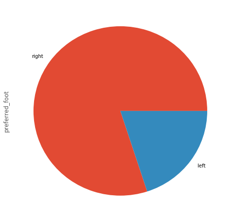

```python
# plot a pie chart and set it's title accordingly
top_50.preferred_foot.value_counts().plot.pie(figsize=(8, 8));
```

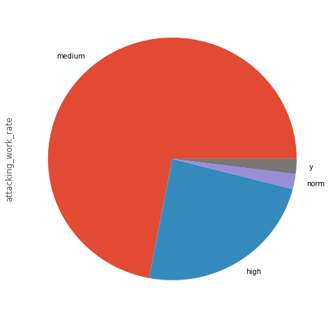

```python
# plot a pie chart and set it's title accordingly

top_50.attacking_work_rate.value_counts().plot.pie(figsize=(8, 8));
```

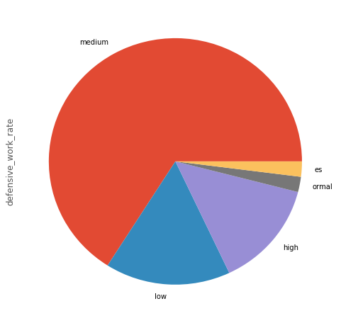

```python
# plot a pie chart and set it's title accordingly

top_50.defensive_work_rate.value_counts().plot.pie(figsize=(8, 8));
```

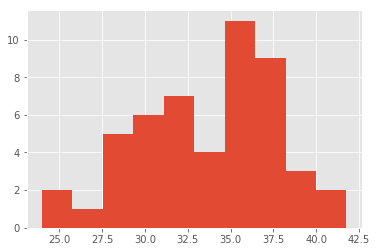

```python
# age distribution for the top players
top_50.age.hist();
```

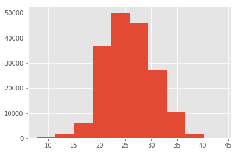

```python
# age distribution for the top players for all players
df_Player_Attributes.age.hist();
```

From this distribution and if we compare it to the distribution of age across all players, we find that the top players are a little older, I think it takes experience and training (hence spending more time at the game) to reach the top!

We can try to see if there are any correlations.

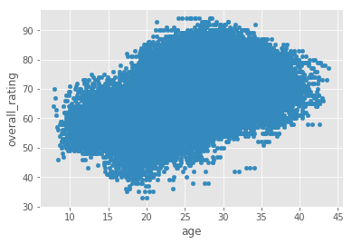

```python
#scatter plot of age and overall_rating
df_Player_Attributes.plot(x='age', y= 'overall_rating', kind = 'scatter');
```

There is a positive correlation between age and overall rating

##### We can also explore all players data to see if there are any correlations

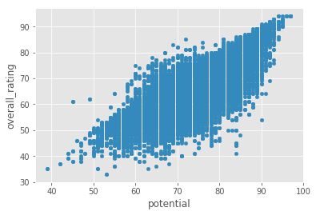

```python
#scatter plot of potential and overall_rating
df_Player_Attributes.plot(y='overall_rating', x= 'potential', kind = 'scatter');
```

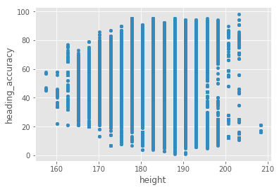

```python
#is there a relationship between height and heading_accuracy?
df_Player_Attributes.plot(x='height', y= 'heading_accuracy', kind = 'scatter');
```

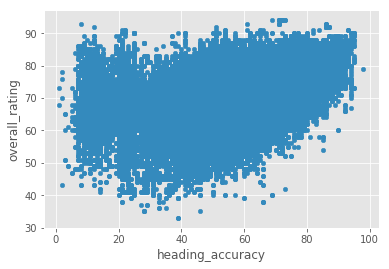

```python
#is there a relationship between overall_rating and heading_accuracy?
df_Player_Attributes.plot(y='overall_rating', x= 'heading_accuracy', kind = 'scatter');
```

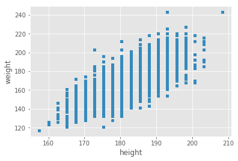

```python
#is there a relationship between height and weight?
df_Player_Attributes.plot(y='weight', x= 'height', kind = 'scatter');
```

Players in this game needs to take care of their bodies indeed!

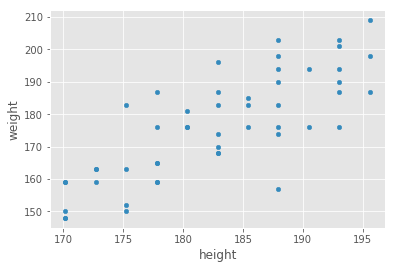

```python
# Same for the top 50 players
top_50.plot(y='weight', x= 'height', kind = 'scatter');
```

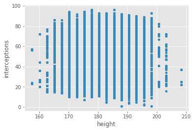

```python
#is there a relationship between height and interceptions?
df_Player_Attributes.plot(y='interceptions', x= 'height', kind = 'scatter');
```

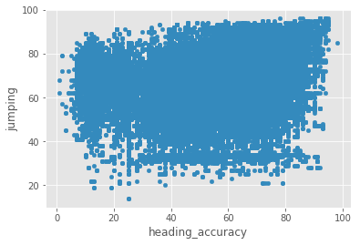

```python
#is there a relationship between jumping and heading_accuracy?
df_Player_Attributes.plot(y='jumping', x= 'heading_accuracy', kind = 'scatter');
```

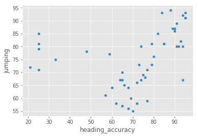

```python
# Same for the top 50 players
top_50.plot(y='jumping', x= 'heading_accuracy', kind = 'scatter');
```

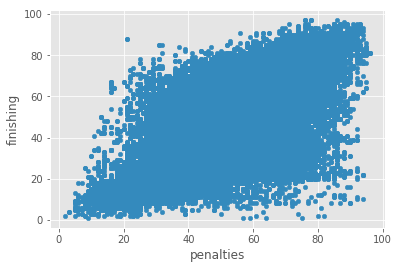

```python
#is there a relationship between finishing and penalties rating?
df_Player_Attributes.plot(y='finishing', x= 'penalties', kind = 'scatter');
```

## Conclusions

### Results:

#### 1. We found that top 10 teams that performed well during this period were:

- FC Barcelona
- Real Madrid CF
- Celtic
- FC Bayern Munich
- Manchester United
- Juventus
- SL Benfica
- FC Porto
- Ajax
- FC Basel  
  They won the most matches in their respective leagues during 2008-2016

#### 2. The league with the max total goals scored per season is:

Spain LIGA BBVA

#### 3. Is there any advantage in playing matches at home?

We found that there is a huge advantage in playing at home, in most of the matches we found that home team winners are more than home team losers, specially in spain, Italy and England. there is no data to see the attributes of this advantage, but we know that it's present and if you are betting, your chances are better if you bet on the home team!

#### 4. which teams are the top performers at home and in away matches?

Top 10 performs at away matches:

- FC Barcelona
- Real Madrid CF
- Celtic
- FC Bayern Munich
- Juventus
- SL Benfica
- FC Porto
- Ajax
- FC Basel
- Manchester United

#### 5. Which teams had the most wins in a single season?

Juventus in 2013/2014 season had the most number of wins in a single season during 2008-2016 period, but we see that FC Barcelona and Real Madrid CF did it through out many different seasons!

#### 6. What teams improved the most over the time period?

Here are the top 10 sorted:

- Paris Saint-Germain
- Atlético Madrid
- Borussia Mönchengladbach
- AS Saint-Étienne
- Juventus
- Aberdeen
- Napoli
- Piast Gliwice
- AS Monaco
- Sporting CP

While the teams the got worse during this period:

- Aston Villa
- FC Twente
- VfB Stuttgart
- Inter
- Wisła Kraków
- Hamburger SV
- Olympique de Marseille
- Dundee United
- FC Zürich
- Manchester United

#### 7. The attributes of the top teams:

Build Up Play Speed Class : Balanced Build Up Play Dribbling Class : Little Build Up Play Passing Class: Mixed Build Up Play Positioning Class: Organized Chance Creation Passing Class : Normal Chance Creation Crossing Class: Normal Chance Creation Shooting Class: Normal Chance Creation Positioning Class: Organized Defense Pressure Class: Medium Defense Aggression Class : Press Defense Team Width Class: Normal Defense Defender Line Class: Cover

### Limitations:

1. Not clear documentaions about the data. we don't know what some columns represent
2. We don't have the postitions of players, because we can't comprare defenders to attackers etc ( we can do deeper analysis of players if we had it.
3. No transfer market data, So we can get the updated player for each team each season